# Load Data

```python
import pandas as pd

df = pd.read_csv('https://storage.googleapis.com/datalynn-datasets/interview-challenge/technology/Microsoft_%20Office365_Collaborative_Filtering/UserActivity.csv')
df.head()
```

|  | UserID | DocumentID | Timestamp | EditDuration | DocumentType | DocumentSize | DocumentTags | PreviousAccess |
| --- | --- | --- | --- | --- | --- | --- | --- | --- |
| 0 | 52 | 22 | 2022-07-25 | 165 | PowerPoint | 0.84 | NaN | 2022-07-18 19:54:00 |
| 1 | 89 | 98 | 2022-08-13 | 64 | Word | 7.43 | NaN | 2022-08-08 10:16:00 |
| 2 | 14 | 169 | 2020-08-17 | 159 | PowerPoint | 5.28 | NaN | 2020-08-11 22:25:00 |
| 3 | 75 | 68 | 2022-06-26 | 126 | PowerPoint | 40.39 | tag1,tag4,tag2,tag3,tag5 | 2022-06-19 08:14:00 |
| 4 | 53 | 197 | 2021-07-01 | 15 | Word | 1.19 | tag2,tag5 | 2021-06-24 00:59:00 |

## Question 1:

**Data Manipulation & Cleaning:**  
*Scenario:* You find out that some users have accessed certain documents even before these documents were tagged or categorized.

Q: Filter the `UserActivity` table to identify records where the `DocumentTags` is missing, and provide a count of such records for each `DocumentType`.

### Hints:

- Filter the dataframe to get where the `DocumentTags` is either missing or empty
- Group the results by `DocumentType` and count

```python
filtered_df = df[df['DocumentTags'].isnull() | (df['DocumentTags'] == '')]
result = filtered_df.groupby('DocumentType').size().reset_index(name='MissingTagsCount').sort_values(by='MissingTagsCount', ascending=False)

print(len(result))
```

```
3
```

## Question 2:

**Probability and Statistics:**  
*Scenario:* Two teams A and B are using SharePoint. You observed that when a member of Team A edits a document, there's a 70% chance that a member of Team B will access it within the next week.

Q: If 5 documents edited by Team A in a week are accessed by Team B, what's the probability that at least 4 of them were accessed within the next week?

### Hints:

- This is a binomial probability problem.
- Break Down the parameters:
  - n (number of trials): The number of documents edited by Team A that were accessed by Team B, which is 5 in this case.
  - p (success probability): The probability that after a member of Team A edits a document, a member of Team B will access it within the next week, which is 70% or 0.7.
  - k (number of successes): This would be the number of documents accessed by Team B within the next week. We want to find the probability that this is at least 4, so we're looking for `P(X >= 4)`, where `X` is the random variable denoting the number of success.

```python
from scipy.stats import binom

# Define parameters
n = 5  # number of trials
p = 0.7  # success probability

# Compute the probability
prob_4 = binom.pmf(4, n, p)  # Probability that exactly 4 documents are accessed
prob_5 = binom.pmf(5, n, p)  # Probability that all 5 documents are accessed

# Summing the probabilities
total_prob = prob_4 + prob_5

print(total_prob)
```

```
0.5282199999999999
```

## Question 3:

**Machine Learning & Modeling:**  
*Scenario:* The Collaborative Filtering team wants to predict the `EditDuration` for a given document based on certain features to help improve the recommendation system.

Q: Build a model using the features `DocumentType`, `DocumentSize`, and `PreviousAccess` to predict the `EditDuration`. Mention which is the target variable and the type of regression model you would use.

*Target Variable:* EditDuration

```python
import pandas as pd
from sklearn.model_selection import train_test_split
from sklearn.ensemble import RandomForestRegressor
from sklearn.metrics import mean_absolute_error
from sklearn.preprocessing import OneHotEncoder

# Convert 'Timestamp' and 'PreviousAccess' to DateTime objects if they are not
df['Timestamp'] = pd.to_datetime(df['Timestamp'])
df['PreviousAccess'] = pd.to_datetime(df['PreviousAccess'])

# One-hot encoding for the 'DocumentType'
encoder = OneHotEncoder(drop='first')  # drop one category to avoid multicollinearity
document_type_encoded = encoder.fit_transform(df[['DocumentType']]).toarray()
encoded_cols = encoder.get_feature_names_out(['DocumentType'])
df_encoded = pd.DataFrame(document_type_encoded, columns=encoded_cols)

# Concatenate encoded features with original df
df = pd.concat([df, df_encoded], axis=1)

# Calculate the difference in hours between 'Timestamp' and 'PreviousAccess'
df['HoursSinceLastAccess'] = (df['Timestamp'] - df['PreviousAccess']).dt.total_seconds() / 3600

# Using the extracted column names from encoder for features
feature_cols = ['DocumentSize', 'HoursSinceLastAccess'] + list(encoded_cols)
X = df[feature_cols]
y = df['EditDuration']

# Split the data into training and testing sets
X_train, X_test, y_train, y_test = train_test_split(X, y, test_size=0.3, random_state=10)

# Train the Random Forest regressor
model = RandomForestRegressor(n_estimators=100, max_depth=15, min_samples_split=15, random_state=10)
model.fit(X_train, y_train)

# Predict and compute the Mean Absolute Error (MAE)
y_pred = model.predict(X_test)
mae = mean_absolute_error(y_test, y_pred)
print(f'Mean Absolute Error: {mae}')
```

```
Mean Absolute Error: 55.613516078867114
```

## Question 4:

**Product Design & Analytics:**  
*Scenario:* The Collaborative Filtering team believes that users tend to access larger documents less frequently, which might affect the recommendation efficiency.

Q: Based on the `UserActivity` table, analyze if there is a significant relationship between `DocumentSize` and the frequency of document access. If there is a relationship, how would you adjust the recommendation system?

### Hints:

- Data preprocessing: calculate the frequency of document access for each `DocumentID`
- Visualization: Use a scatter plot to inspect the relationship.
- Statistical Testing: Use Pearson's correlation coefficient to measure the strength and direction of the linear relationship between two variables

```
Pearson Correlation Coefficient: 0.060547627630878766
P-value: 0.3955873117219843
```

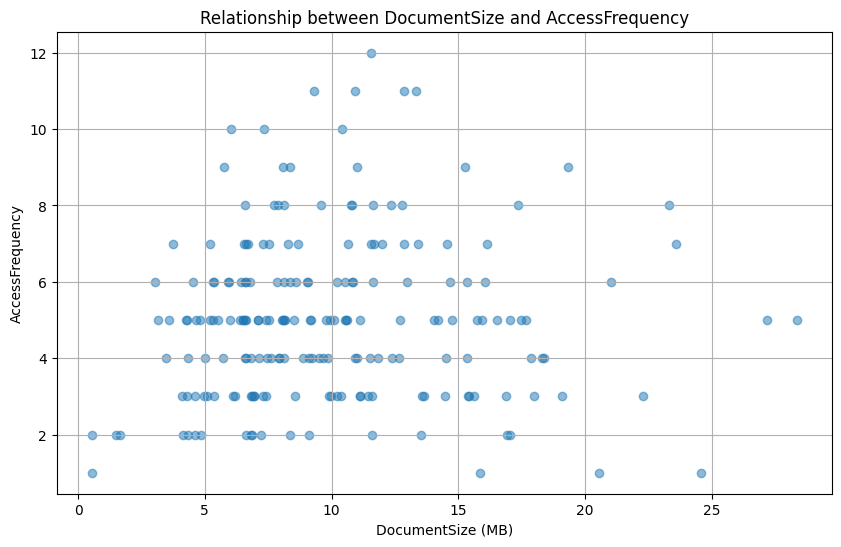

```python
import matplotlib.pyplot as plt
from scipy.stats import pearsonr

# Calculate the frequency of document access
document_frequency = df.groupby('DocumentID').size().reset_index(name='AccessFrequency')

avg_document_size = df.groupby('DocumentID')['DocumentSize'].mean().reset_index()

merged_data = pd.merge(document_frequency, avg_document_size, on='DocumentID')

correlation_coefficient, p_value = pearsonr(merged_data['DocumentSize'], merged_data['AccessFrequency'])

print(f'Pearson Correlation Coefficient: {correlation_coefficient}')
print(f'P-value: {p_value}')

plt.figure(figsize=(10, 6))
plt.scatter(merged_data['DocumentSize'], merged_data['AccessFrequency'], alpha=0.5)
plt.title('Relationship between DocumentSize and AccessFrequency')
plt.xlabel('DocumentSize (MB)')
plt.ylabel('AccessFrequency')
plt.grid(True)
plt.show()
```

- Since the p-value > 0.05 (significance level), the relationship between the two variables is not statistically significant.
- Also, the Pearson Correlation Coefficientis also very small on the scale of -1 to 1, which mean the direction of the relationship between these two variable is positive but not strong.